# 隨機變數與機率分布函數、機率密度函數

## 定義隨機變數

- \(S\) 是一個事件空間，如果\(X : S \rightarrow \mathbb{R}\)是一個把\(S\)中的元素\(s\)對應到實數\(\mathbb{R}\)的函數，則\(X\)是一個隨機變數。

### 範例

- 投擲兩個骰子，\(X\)代表骰子點數的和
- 1000個產品，\(X\)代表總共需要維修的產品數量
- 種植玉米，\(X\)代表平均每畝農地中的收穫量

## 隨機變數的函數

如果\(Y\)是另一個從實數到實數的函數，那\(Y \circ X\) 也是隨機變數。

\[Y \circ X(s) = Y( X(s) )\]

### 範例

- 投擲兩個骰子，判斷骰子點數的和是不是偶數
  - \(X\) 代表骰子的點數和
  - \(Y\) 代表「是不是偶數」的函數
- 1000個產品，\(X\)代表總共需要維修的產品數量，\(Y\)代表維修的總開銷

## 隨機變數的分布

- \(X = x_i\) 的機率，就是所有\(s\)使得\(X(s) = x_i\)的機率的和

\[P_X(X = x_i) = P(\{s_j \in S | X(s_j) = x_i\}) = P(X^{-1}(x_i))\]

### 範例

- 投擲兩個骰子，\(X\)代表骰子點數的和
  - \(P_X(X = 1) = 0\)
  - \(P_X(X = 2) = P(\{(1,1)\}) = \frac{1}{36}\)
  - \(P_X(X = 3) = P(\{(1,2),(2,1)\}) = \frac{2}{36}\)

## 累積分布函數

- 隨機變數\(X\)的累積分布函數(CDF)\(F_X\)定義為：

\[F_X(x) = P(X \leq x)\]

### 範例

- 投擲兩個骰子，\(X\)代表骰子點數的和
  - \(F_X(0) = 0\)
  - \(F_X(2) = \frac{1}{36}\)

## 累積分布函數

### 範例

- 投擲兩個骰子，\(X\)代表骰子點數的和

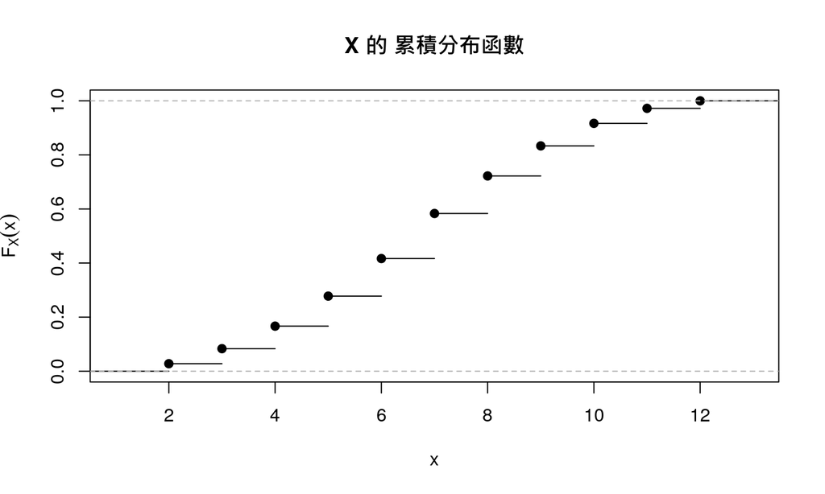

## 累積分布函數的特性

- \(\lim_{x \rightarrow -\infty}F_X(x) = 0\)、\(\lim_{x \rightarrow \infty}F_X(x) = 1\)
- \(F_X\)不會遞減：若\(a > b\)則\(F_X(a) \geq F_X(b)\)

## 相等的隨機變數

- 隨機變數\(X\)與隨機變數\(Y\)如果**分布相同**，則代表對所有\(x\)：

\[F_X(x) = F_Y(x)\]

## 機率質量函數

- 隨機變數\(X\)的**機率質量函數**(PMF)的定義是：

\[f_X(x) = P(X = x)\]

### 範例

- 投擲兩個骰子，\(X\)代表骰子點數的和
  - \(f_X(1) = 0\)
  - \(f_X(2) = P(\{(1,1)\}) = \frac{1}{36}\)
  - \(f_X(3) = P(\{(1,2),(2,1)\}) = \frac{2}{36}\)

## 機率密度函數

- 如果\(F_X\)是連續函數，則機率密度函數(PDF)\(f_X\)定義為滿足以下條件的函數：

\[F_X(x) = \int_{-\infty}^{x} f_X(t) dt\]

### 範例：\(F_X(0) = \int_{-\infty}^0 f_X(t) dt\)

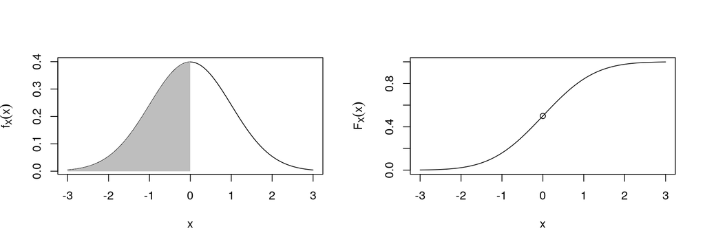

## 離散的隨機變數與連續的隨機變數

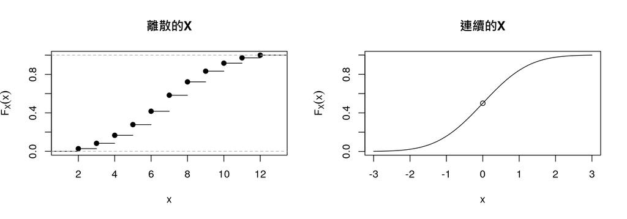

### 如果\(X\)是在 x 連續的隨機變數

- \(P(X = x) = 0\)
- \(P(X < x) = P(X \leq x)\)、\(P(X > x) = P(X \geq x)\)